# M-you-sic

### Chart 2: Mapping

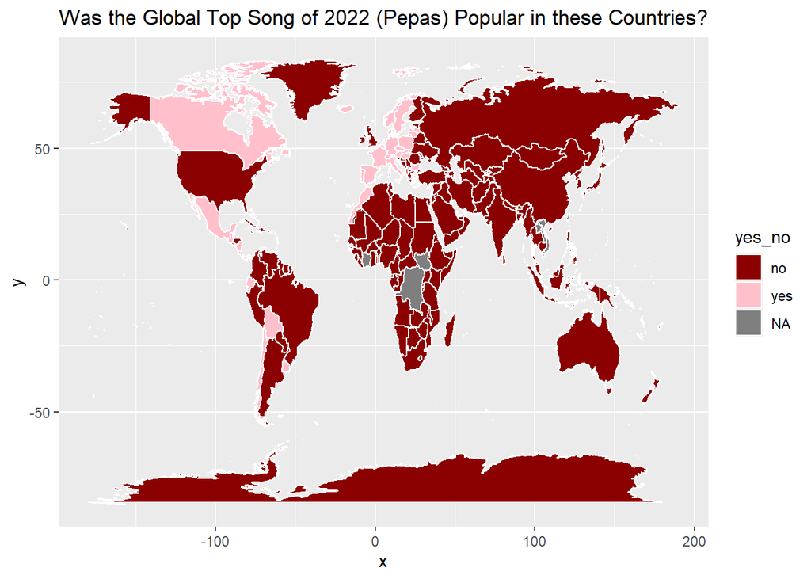

### Chart 3: Pie Chart

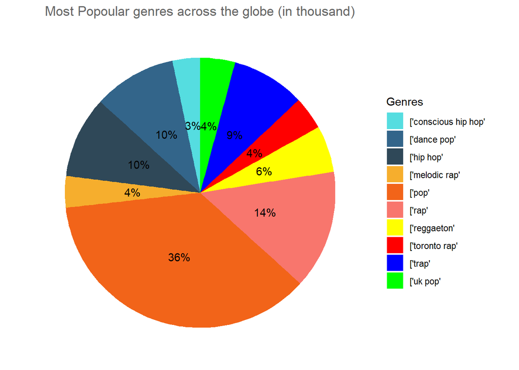

This chart summarizes the top 10 most favorable genres across the globe. The purpose of this is to ascertain which genre is most popular. Therefore that genre can eventually be used to bridge the gap between people from different cultures in terms of musical ideas and thoughts. For example, according to the data, pop is the most popular music genre. So when in conversations, people can start off the topic by pointing out who your favorite pop star is or what their favorite pop music is. This result can also be used for later studies to explore why “pop” has become the star of music.